# Отчёт по лабораторной работе 4-C

Захват backup-сервера

Козлов В.П.

Гэинэ А.

Шуваев С.

Джахангиров И.З

Хватов М.Г.

Российский университет дружбы народов им. Патриса Лумумбы, Москва, Россия

## Докладчик

- Козлов В.П., Шуваев С.
- НФИбд-02-22
- Российский университет дружбы народов

# Выполнение лабораторной работы

## Цель работы

Данный сценарий посвящён атаке на внутренний резервный сервер (backup-сервер) организации с целью получения конфиденциального флага. В ходе выполнения работы демонстрируются этапы разведки внутренней сети, поиска уязвимого хоста и эксплуатации уязвимости MS17-010 (EternalBlue) для получения доступа к файловой системе. Финальной задачей является извлечение файла flag.txt, содержащего ответ на задание.

## Задание

1. Получите доступ к сети через уязвимость на корпоративном сайте или почтовом сервере, создав meterpreter-сессию.
2. Исследуйте внутреннюю сеть, добавьте маршрут и найдите активные хосты с помощью сканирования ARP.
3. Найдите backup-сервер, отсканировав открытые порты (SMB 445, FTP 21) на найденных хостах.
4. Проверьте и эксплуатируйте уязвимость MS17-010 на найденном сервере, получив на него сессию с правами SYSTEM.
5. Найдите и прочитайте флаг в файле flag.txt.

## Обнаружил уязвимые полигоны

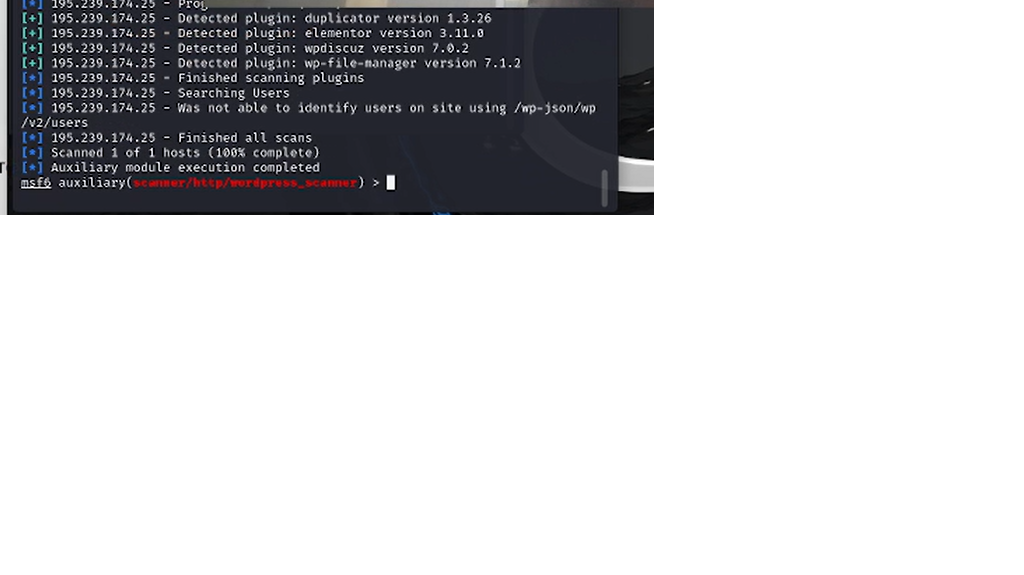

Уязвимые полигоны

## Нашел эксплойт для WpDiscuz и выбрал подходящий модуль

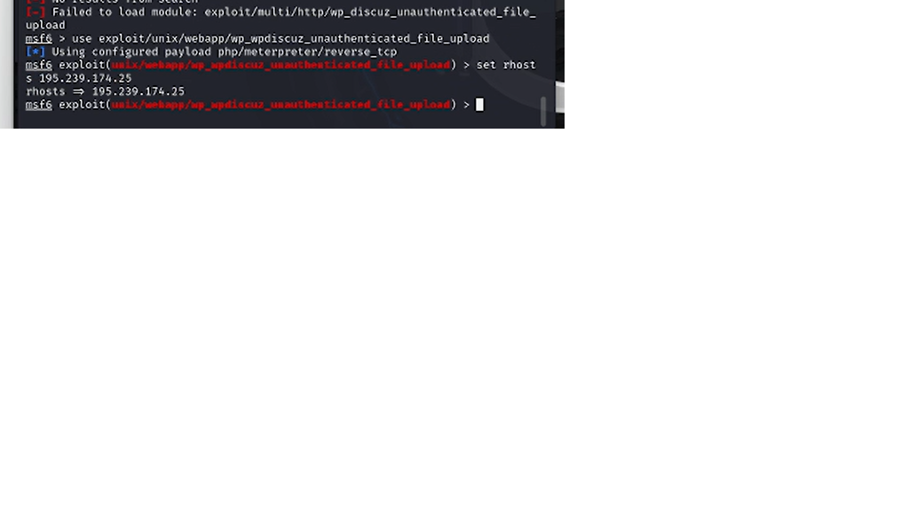

Эксплойт для WpDiscuz

## Настроил параметры эксплойта

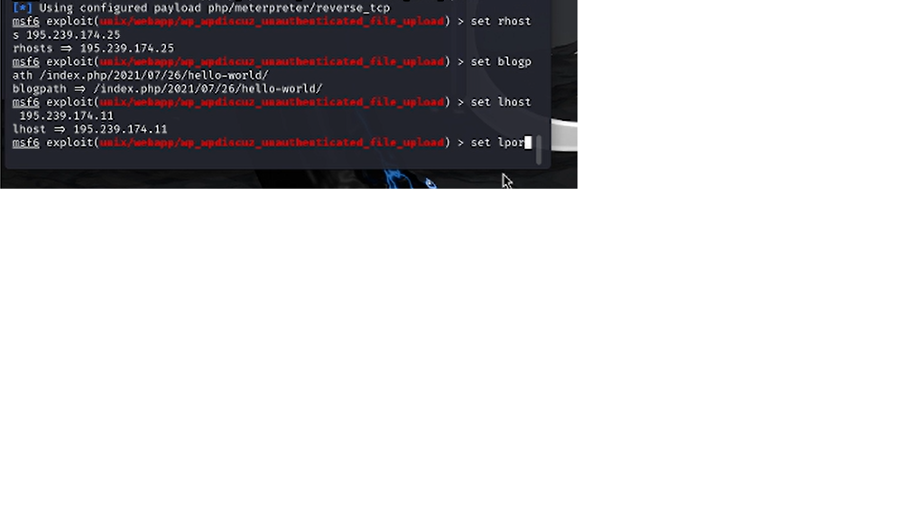

Параметры эксплойта

## Получил доступ к www-data

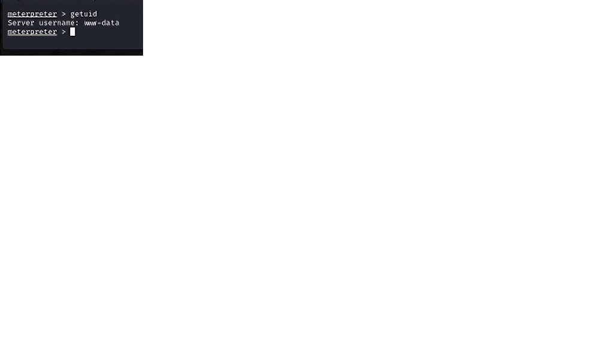

Доступ к www-data

## Добавил маршрут до внутренней подсети

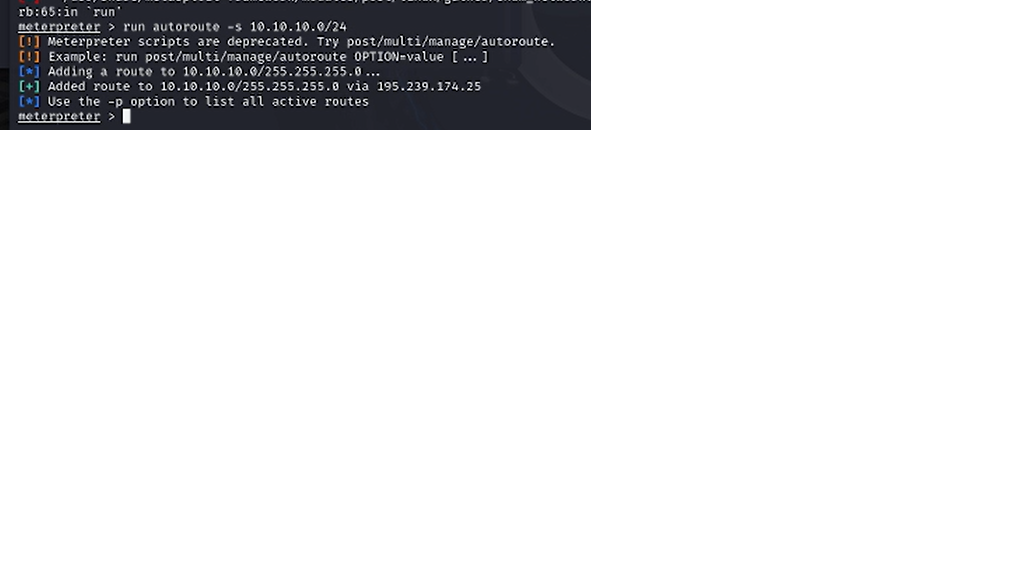

Маршрут до внутренней подсети

## Запуск прокси-сервера

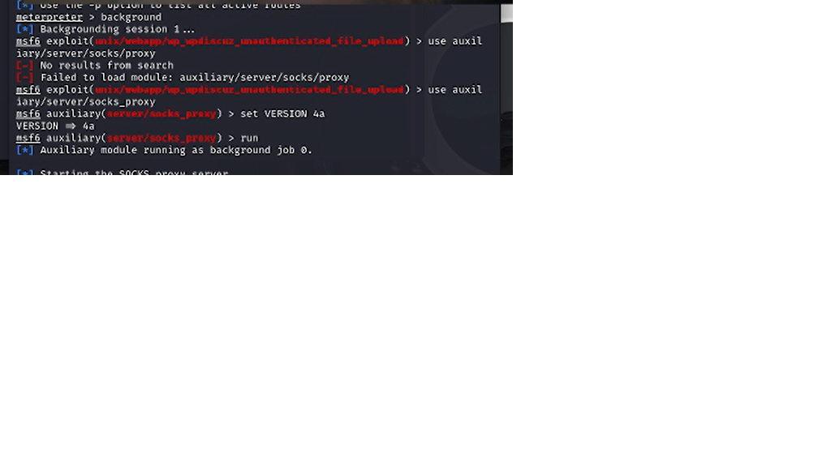

Запуск прокси-сервера

## Сканирование backup-сервера

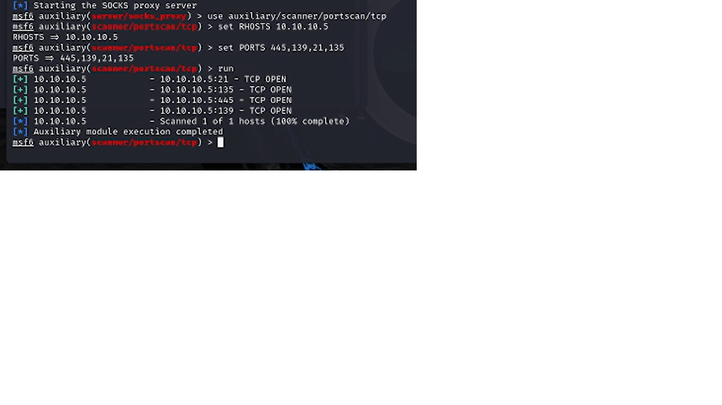

Сканирование backup-сервера

## Эксплуатация уязвимости

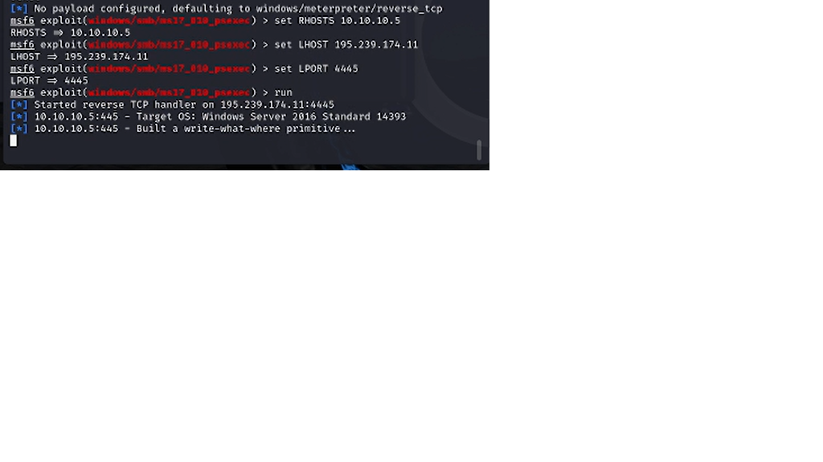

Эксплуатация уязвимости

## Нашел местоположение файла

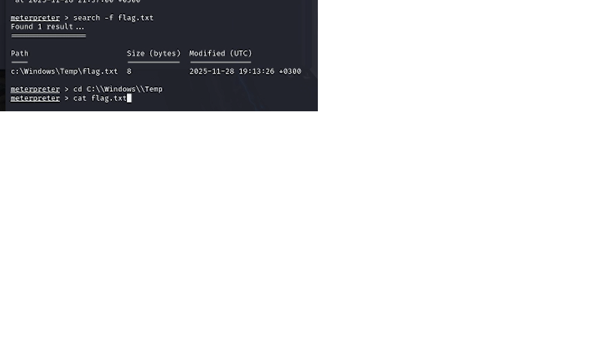

Местоположение файла

## Содержимое файла

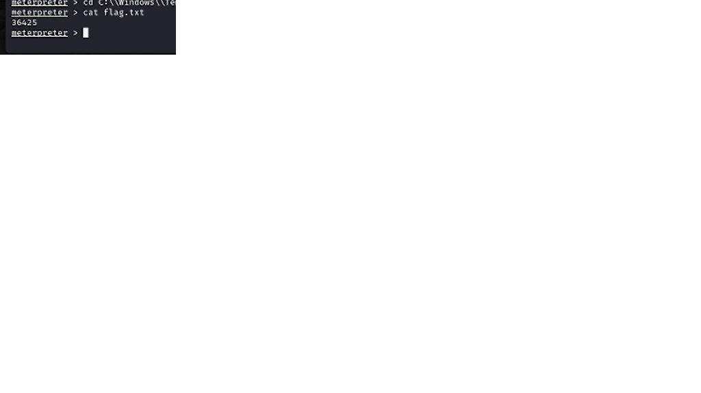

Содержимое файла

## Ответ подошел

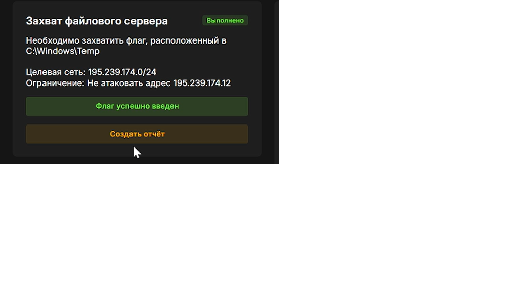

Ответ подошел

## Выводы

Сценарий показал, как устаревшее ПО (уязвимость MS17-010) на внутреннем сервере позволяет злоумышленнику, получившему доступ к сети, быстро захватить контроль над критическим ресурсом (backup-сервером). Это подтверждает важность регулярного обновления систем и строгой сегментации сети даже внутри защищённого периметра.